# HomeDepot First Data Exploration

Brian Carter

19 February 2016

An initial analysis of the data in the *train.csv* file from the Home Depot Competion. (Where new variables created, prefix with a *c.*) There are four files of interest for exploration *(train.csv,test.csv,product_descriptions.csv,attributes.csv,sample_submission)*.

The *sample_submission.csv* file and the *test.csv* file have the same number of rows, 166693.

# train.csv and test.csv Overlap.

There are 74067 rows in the *train.csv* data and 166693 in the *test.csv* data. Both have the same columns [id, product_uid, product_title, search_term, relevance] bar the **relevance** score which is not included in the *test.csv* data. Examining the column **product_id** there are 54667 unique values in the *train.csv* data and and 97460 in the *test.csv* data. There are total of 27699 **product_uid** values that intersect. This is displayed below in a venn diagram.

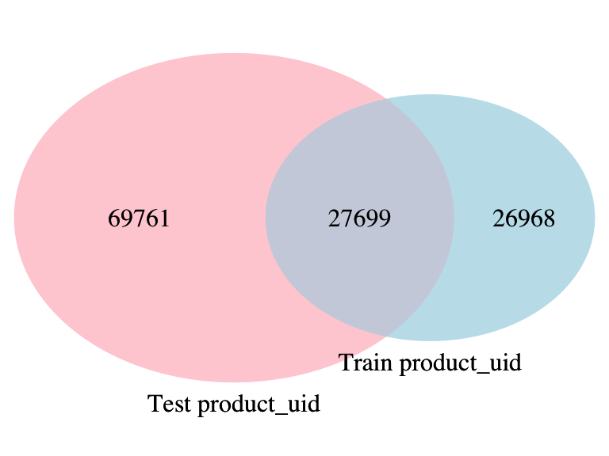

```r
#Count unique *product_uid*, the PK across datasets.
pidTrain = unique(hdTrain[,product_uid])
pidTest = unique(hdTest[,product_uid])
pidAtt = unique(hdAtt[,product_uid])
pidDesc = unique(hdDesc[,product_uid])

#Create venn diagram to represent the relationship between Product IDs across both.

#install.packages("VennDiagram")
library(VennDiagram)

grid.newpage()

venn.plot1<-draw.pairwise.venn(
    length(pidTrain),length(pidTest),length(intersect(pidTrain,pidTest)),
    category = c("Train product_uid", "Test product_uid"),
    lty = rep("blank",2),
    fill = c("light blue", "pink"),
    alpha = rep(0.5, 2),
    cat.pos = c(0,0),
    cat.dist = rep(0.025, 2))

grid.draw(venn.plot1)
```

There are a total of 54667 unique **product_uid** in the *train* and 97460 in *test*. Of these only 27699 are common. The total number of unique *product_uids* across both the *train* and *test* is 124428. This equals the total number of **product_uid** and **rows** in the *product_descriptions.csv* file,(TRUE).

In the *attributes.csv* file, there are a total of 2044803 **rows** and a total of 86264 unique **product_uid**. The interesection of **product_uid** across the three files *(train,test,attributes)* is displayed in the venn diagram below.

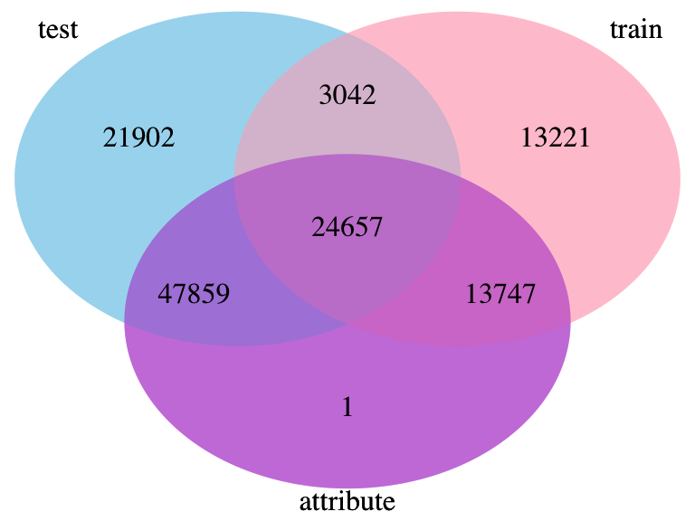

There is one value in *attributes.csv* file that is not in either the *Train* or *Test* files. On investigating this there are 155 rows that do not have a *product_uid* value. These rows can be removed.

```r
hdAtt<-hdAtt[!is.na(product_uid),]
```

# train.csv Data Exploration

The target variable is the **relevance** score. In the supplied *relevance_instructions.cocx* file supplied to the human graders it instructs to provide a relevance grade of either;

- Irrelevant (1)
- Partially or somewhat relevant (2)
- Perfect match (3).

Further more in the competition data it states that *Each pair [search_term,product] was evaluated by at least three human raters. The provided relevance scores are the aveerage value of the ratings*. There are a total of 13 unique values for **relevance** in the *train* data. A bar-chart of their frequency is displayed below.

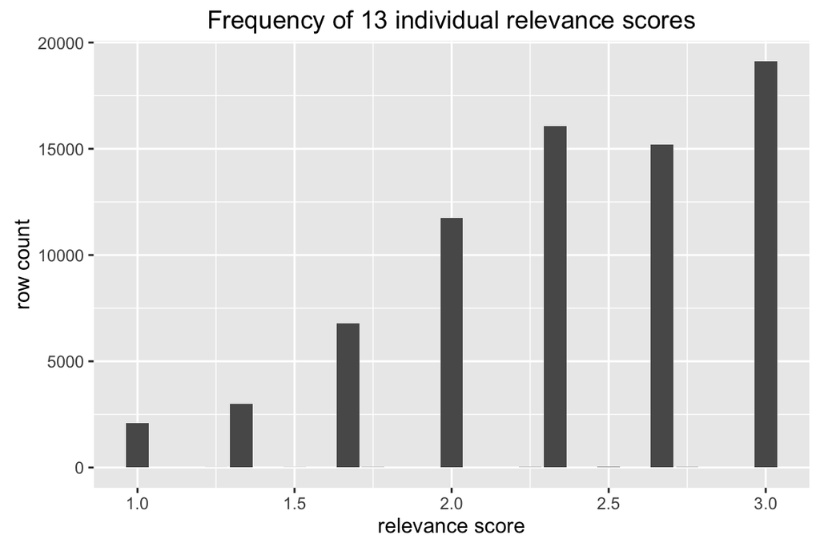

```r
library(ggplot2)
ggplot(hdTrain,aes(relevance))+geom_bar()+labs(title="Frequency of 13 individual relevance scores",x="relevance score",y="row count")
```

Note there are a set of **relevance** scores that occur with low frequenices (1.25,1.5,1.75,2.25,2.5,2.75), thus indicating that perhaps more than 3 or less than 3 human evaluators appraised that row.

```r
#Create frequency table for printing
mytable<-data.frame(table(hdTrain$relevance))
names(mytable)<-c("Rel. Score","Frequency")
tab_nums("relFreq","Count of frequency of the relevance score")
```

```
## [1] "Table  1: Count of frequency of the relevance score"
```

```r
pander(mytable,caption=tab_nums("relFreq"),split.table=60,justify=c("left"),table.alignment="center")
```

| Rel. Score | Frequency |
| --- | --- |
| 1 | 2,105 |
| 1.25 | 4 |
| 1.33 | 3,006 |
| 1.5 | 5 |
| 1.67 | 6,780 |
| 1.75 | 9 |
| 2 | 11,730 |
| 2.25 | 11 |
| 2.33 | 16,060 |
| 2.5 | 19 |
| 2.67 | 15,202 |
| 2.75 | 11 |
| 3 | 19,125 |

Table 1: Count of frequency of the relevance score

Table 1 displays the count of the frequecies of the **relevance** scores. There are 59 rows in the *train* data that relate to these infrequent values, representing 0.0797% of the total rows. It seems these are anomalies that could be removed. For the remainder of the exploratory analysis they are removed.

```r
hdTrain<-hdTrain[!relevance %in% c(1.25,1.5,1.75,2.25,2.5,2.75),]
```

The average **relevance** score is examined by nummber of times a **product_uid** occurs in the dataset.

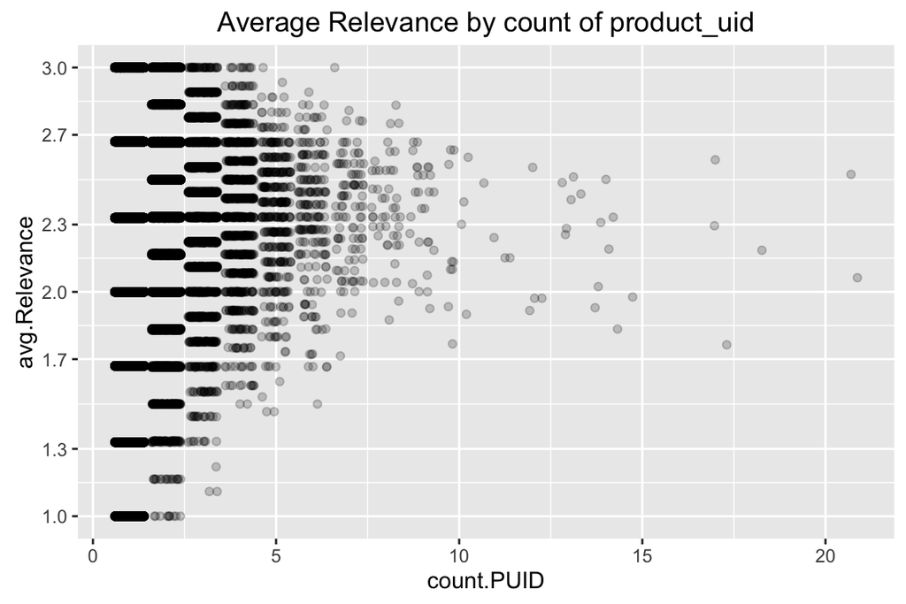

```r
hdTrain %>%
    group_by(product_uid) %>%
    summarize(count.PUID=.N,avg.Relevance=mean(relevance,na.rm=TRUE)) %>%
    ggplot(aes(x=count.PUID,y=avg.Relevance,group=1)) +
    geom_jitter(alpha=0.2) +
    scale_y_continuous(breaks = round(seq(1,3,by = 0.333),1))+
    labs(title="Average Relevance by count of product_uid")
```

As expected the variation of the **relevance** decreases as the number of times a *product_uid* occurs in the dataset. The **relevance** score is examined in the context of the number of parameters (words) in a **search_term**.

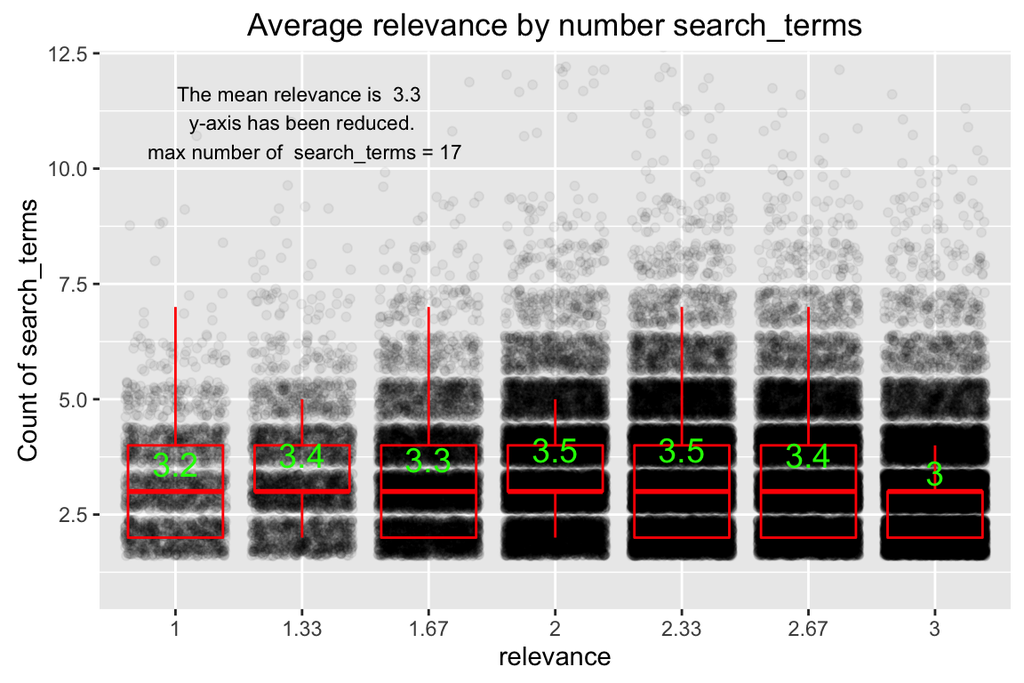

```r
#count the number of search terms
hdTrain<-hdTrain[,c.count_search_term:=sapply(gregexpr("\\W+", search_term), length) + 1,]

#Create averages for annotating the plot
avgST<-round(mean(hdTrain$c.count_search_term),2)
avgSTGroup<-hdTrain %>% group_by(as.factor(relevance)) %>% summarise(groupMean=round(mean(c.count_search_term),1))
names(avgSTGroup)=c("relevance","grpMean")

#Create plot, limit y-axis,add overlay boxplot, annotate with meanby group and text.
plotText<-paste("The mean relevance is ",avgST,"\ny-axis has been reduced.\n max number of  search_terms =",max(hdTrain$c.count_search_term))

hdTrain %>%
    ggplot(aes(x=factor(relevance),y=c.count_search_term)) +
    geom_jitter(alpha=0.05) +
    coord_cartesian(ylim=c(1,12)) +
    geom_boxplot(color = "red", outlier.colour = NA, fill = NA)+
    geom_text(data = avgSTGroup, aes(x = relevance, y = grpMean, label = grpMean), size = 5, vjust = -0.25,colour="green")+
    annotate("text",label=plotText,x=2,y=11,size=3,colour="black")+
    labs(title="Average relevance by number search_terms",x="relevance",y="Count of search_terms")
```

The Jaccard Similarity Coefficent between {**search_term**} and the {**product_title**} is caculated and plotted against the **relevance score**.

$$JC(A,B) = \frac{|A \cap B|}{|A \cup B|} = \frac{|A \cap B|}{|A|+|B| - |A \cap B|}$$

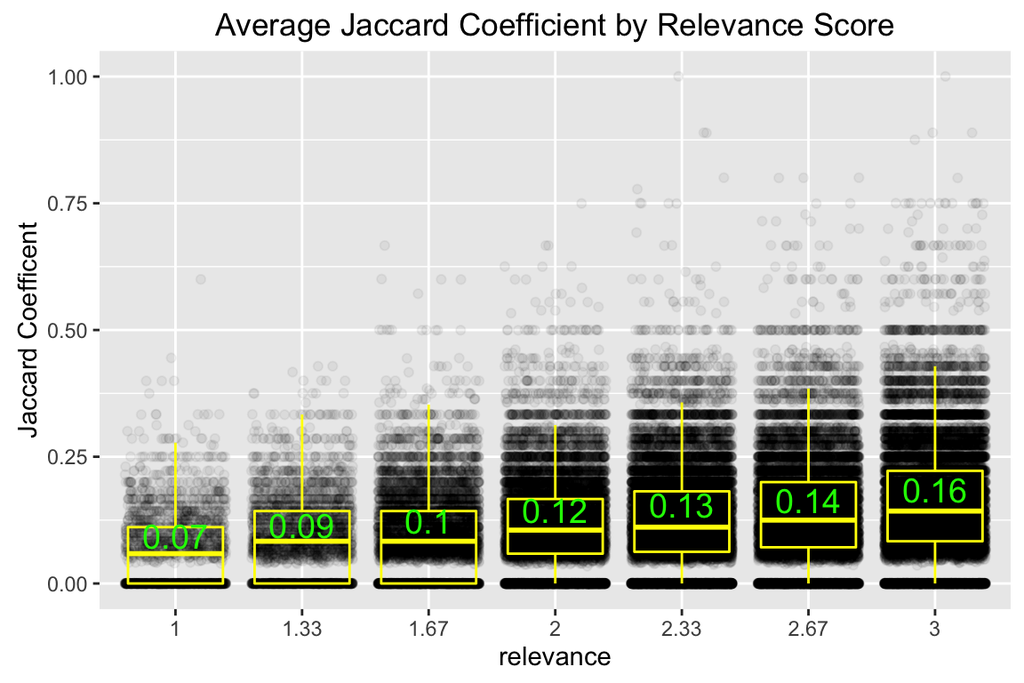

```r
#Function for calculating JC
calcJacCoef<-function(A,B){

    #Using library(sets) for calculating Jacard Coefficent.
    ### Note it the warning messages: %>% is masked from package:dplyr, set is masked from package:data.table
    ### Deatch it after its use otherwise gets annoying.
    require(sets)

    A<-gset(strsplit(A, " ")[[1]])
    B<-gset(strsplit(B, " ")[[1]])
    return(gset_similarity(A,B,"Jaccard"))

    detach("package:sets",unload=TRUE)
    #use search() to check if unloaded
}

#Calculate the Jaccard Coefficient between the *search_term&* and *product_title* for each row in hdTrain
#Takes time to calculate.
hdTrain<-hdTrain[,search_terms:=tolower(search_term)]
hdTrain<-hdTrain[,product_title:=tolower(product_title)]
hdTrain<-hdTrain[,c.Jaccard.ST_PT := calcJacCoef(search_term,product_title),by = 1:nrow(hdTrain)]

detach("package:sets",unload=TRUE)
#use search() to check if unloaded

#Create averages for annotating the plot
avgJC<-round(mean(hdTrain[,c.Jaccard.ST_PT]),2)
avgJCGroup<-hdTrain %>% group_by(relevance) %>% summarise(groupMean=round(mean(c.Jaccard.ST_PT),2))
names(avgJCGroup)=c("relevance","grpMean")


hdTrain %>%
    ggplot(aes(x=factor(relevance),y=c.Jaccard.ST_PT)) +
    geom_jitter(alpha=0.05) +
    geom_boxplot(color = "yellow", outlier.colour = NA, fill = NA)+
    geom_text(data = avgJCGroup, aes(x = factor(relevance), y = grpMean, label = grpMean), size = 5, vjust = 0,colour="green")+
    labs(title="Average Jaccard Coefficient by Relevance Score",x="relevance",y="Jaccard Coefficent")
```

# Bring in attributes.csv

There are 2044648 rows in the *attributes.csv* file. These relate to 86263 unique products. The plot below show displays a the **relevance** by those products in the *attributes* and those that are not.

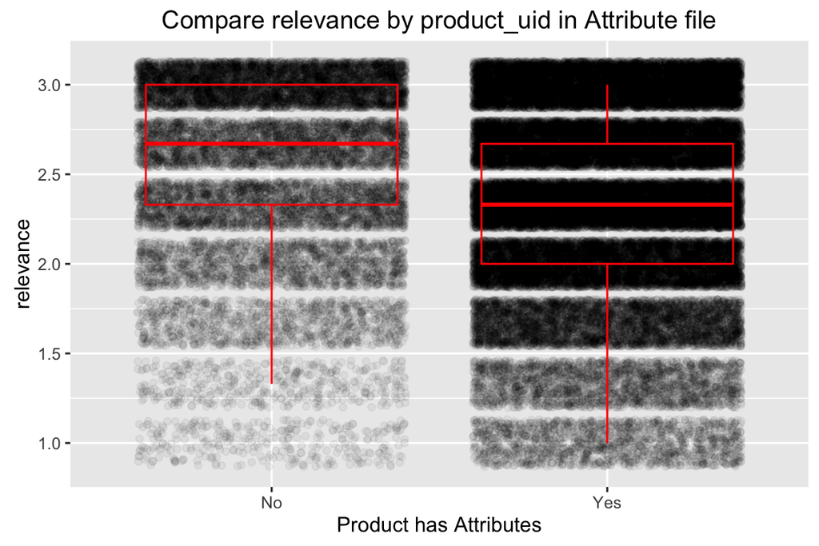

In the attributes file there are 5343 different categories(**name**) of *attributes*.

```
## [1] "Table  2: Count of Top 10 Freq. of categories in attribute.csv"
```

| Attribute.name | Freq. |
| --- | --- |
| mfg brand name | 86,250 |
| bullet02 | 86,248 |
| bullet03 | 86,226 |
| bullet04 | 86,174 |
| bullet01 | 85,940 |
| product width (in.) | 61,137 |
| bullet05 | 60,529 |
| product height (in.) | 54,698 |
| product depth (in.) | 53,652 |
| product weight (lb.) | 45,175 |

Table 2: Count of Top 10 Freq. of categories in attribute.csv

```
## [1] "Table  3: Count of Top 10 Freq. of Colour categories"
```

```
## [1] "Table  4: Count of Top 10 Freq. of Brand categories"
```

There are 63 **name** that refer to a color, aspect of the product in the *attribute file*. Similarly there are 10 that refer to brand aspect. A sorted count of the top 10 for each are are displayed below.

| Attribute.name | Freq. |
| --- | --- |
| color family | 41,508 |
| color/finish | 28,564 |
| color | 6,222 |
| color/finish family | 4,630 |
| fixture color/finish | 4,119 |
| fixture color/finish family | 2,256 |
| shade color family | 2,006 |
| actual color temperature (k) | 1,421 |
| color rendering index | 1,118 |
| top color family | 996 |

Table 3: Count of Top 10 Freq. of Colour categories

| Attribute.name | Freq. |
| --- | --- |
| mfg brand name | 86,250 |
| brand/model compatibility | 681 |
| brand compatibility | 609 |
| fits faucet brand | 550 |
| fits brands | 407 |
| fits brand/models | 168 |
| fits brands/models | 119 |
| pump brand | 87 |
| fits brand/model | 6 |
| brand/model/year compatibility | 4 |

Table 4: Count of Top 10 Freq. of Brand categories

The **name=mrg brand name** appears to be the standard for Brand attributes. For color the information is spread acorss multiple fields. Create two flags in the *Train* indicating if a **product_uid** has brand and color attribute information.

```r
#First change hdAtt tolower
hdAtt<-hdAtt[,name:=tolower(name)]

hdTrain<-hdTrain[product_uid %in% unique(hdAtt[name %like% "colo*r",product_uid]),c.hasColorAtt:="Yes"]
hdTrain<-hdTrain[is.na(c.hasColorAtt),c.hasColorAtt:="No"]

hdTrain<-hdTrain[product_uid %in% unique(hdAtt[name == "mfg brand name",product_uid]),c.hasBrandAtt:="Yes"]
hdTrain<-hdTrain[is.na(c.hasBrandAtt),c.hasBrandAtt:="No"]
```

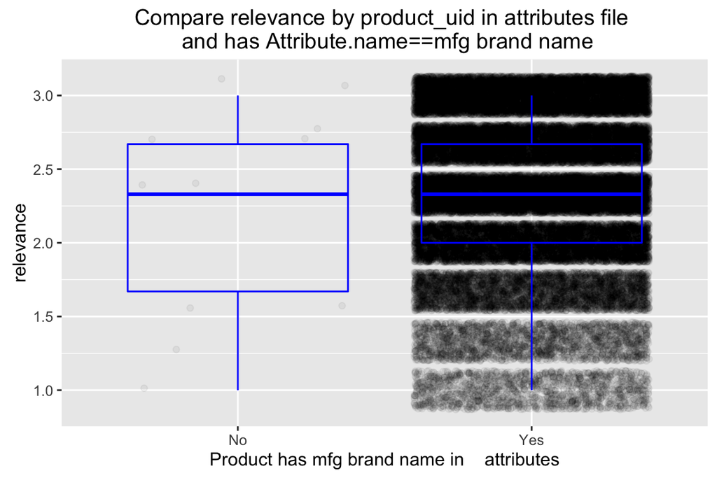

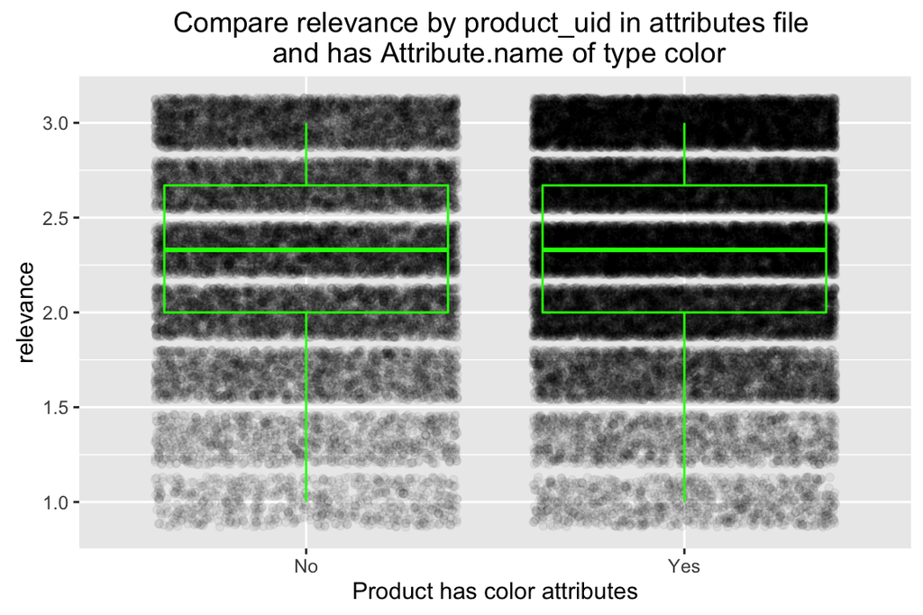